# Visualizing Twitter Data - Project Presentation

CJ/Sijie Shan

December 17, 2017

## Project Goal

Twitter, created in March 2006, rapidly gained worldwide popularity. In 2012, more than 100 million users posted 340 million tweets a day[^1]. In the third quarter of 2017, the number of monthly active Twitter users has surged to 330 millions. Along with the growing popularity of Twitter comes an abundance of available data. The current project will make use of available data on Twitter and visualizes most-used words of any Twitter account in a word cloud.

## Word Use of @BU_Tweets

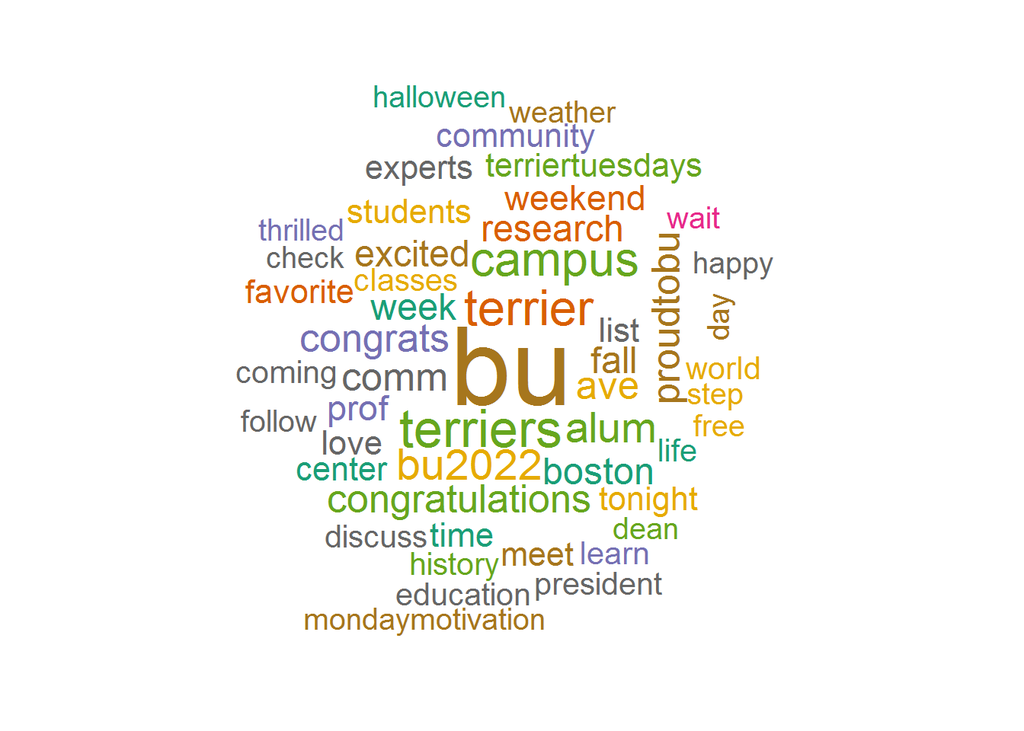

Above is an example word cloud of most-used words on Boston university Twitter account - the more often a word is being used, the larger the word appears. Not surprisingly, we saw repeated use of words like “bu” and “terriers.”

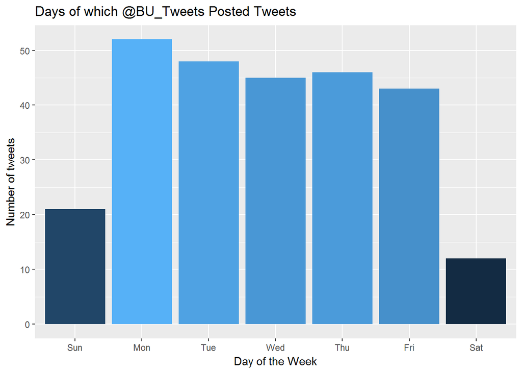

We can also see from the above plot that @BU_Tweets mostly posts on weekdays - looks natural as a school Twitter account.

```r
geocode("Boston University") # location of BU
```

```
##     lon  lat
## 1 -71.1 42.4
```

Unfortunately, all of tweets posted by BU are not geocoded - as a matter of fact, a random sample of 1.5 million public tweets by 10,000 users over 18 months reports that 95% of users never geotag a single tweet.[^2] But still, we can draw a map of peripheral of BU.

[figure not shown]

[^1]: Twitter (March 21, 2012). “Twitter turns six”. Twitter
[^2]: https://www.quora.com/What-percentage-of-tweets-are-geotagged-What-percentage-of-geotagged-tweets-are-ascribed-to-a-venue